# Overview of Quarto in RStudio Environment

Part of Workshop Entitled “Introduction to Quarto: Quarto’s Capabilities for Work and School Planning Board”

Jae Min Jung, Ph.D.

Professor of Marketing & Director of CCIDM and MS in Digital Marketing

2/02/2025

# R and RStudio

- Brief History
- Installation
  1. R: https://www.r-project.org/
  2. RStudio:
     - Desktop https://posit.co/download/rstudio-desktop/
     - Posit Cloud: https://posit.cloud/
- R Studio IDE menu (Next slide)
- Three major file types in RStudio (Next slide)

# RStudio IDE

- Four quadrants
- Menu
  - Tools > Global Options
  - Output location options
    - Manually set `working directory`
    - Automatic method with the `Rproj` file (Next slide)

# Steps in Preparing for a project

## 1. Start a new project

- Projects are the containers for all of your notebooks.

```
1.  From File, click `new project`
2.  Select a new or existing directory depending on your needs
3.  Select your folder that will contain your project.
4.  Press create project
```

- You should see your `.Rproj` file and others in the `Files` panel

## 2. Start a codebook/notebook and save it

- R Scripts file
- Rmd file
- Quarto file

### Markdown vs. HTML

Markdown and HTML are both markup languages used for creating formatted content, but they have distinct characteristics. Here’s a summary of their similarities and differences:

| **Feature** | **Markdown** | **HTML** |
| --- | --- | --- |
| Syntax complexity | Simple and easy to read | More complex with specific tags |
| Learning curve | Low, quick to learn | Steeper, requires more time to master |
| Readability | Highly readable, even in raw form | Less readable in raw form |
| Flexibility | Limited formatting options | Highly flexible with extensive formatting |
| Output | Primarily static content | Dynamic web pages and applications |
| Supported elements | Basic formatting (headings, lists, links) | Wide range of elements (forms, multimedia) |
| Conversion | Easily converts to HTML | Cannot be directly converted to Markdown |
| Collaborative editing | Well-suited for collaboration | Less ideal for collaborative editing |
| Customization | Limited styling options | Extensive styling with CSS |
| Use cases | Documentation, simple content | Complex web development, detailed layouts |
| Browser support | Requires conversion to HTML | Natively supported by browsers |
| Extensibility | Limited, varies by flavor | Highly extensible with JavaScript |

## 3. Start literate coding

# What is Quarto?

- Quarto is an open-source technical publishing system designed for creating a wide variety of documents and publications (https://quarto.org/)
- Support multiple coding languages:
  - R, Python, Julia, ObservableJS
- Supported by multiple IDEs
  - RStdudio, VS Code, Jupyter, Neovim
- Publish to multiple hosting services
  - QaurtoPub, GitHub Pages, Posit Connect, Netlify, Hugging Face, etc.
- Great for **reproducible research/publications/documents**.

Figure 1 is from [YouTube video](https://www.youtube.com/watch?v=8qR0wtJEDX4) by Christophe Dervieux, *Posit PBC*.

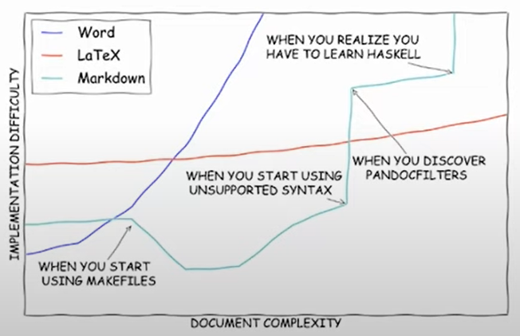

Figure 1

## Quarto Work Flow Basics (Demo)

- How to start it and save it (e.g., test.qmd)
- Rendering it:
- Source vs. visual tab interface
- r4ds: https://r4ds.hadley.nz/quarto#quarto-basics

## Three Areas in Quarto File

- Detailed tutorials available at [the official Quarto site](https://quarto.org/docs/get-started/hello/rstudio.html)

### 1. Yaml header

An YAML header demarcated by three dashes (`---`) on either end.

```
---
title: "Module 1 Introduction to R, RStudio, and Qurto"
author: "Jae Jung"
date: '2025-02-02 22:33:43'
format:
  html:
    toc: true
    toc-depth: 4
    embed-resources: true
editor: visual
execute:
  freeze: auto
---
```

### 2. Code chunk

````markdown
```{r}
#| label: demo-code-chunk
#| include: true

#install.packages("tidyverse")
#install.packages("palmerpenguins")
library(tidyverse)
library(palmerpenguins)
```
````

### 3. Markdown text area

- Text area is all the canvas area within qmd file other than Yaml header and code chun areas.
- Quarto uses markdown syntax for text.
- You can use text area for typing prose as you would normally do in MS Word or Google Doc.
  - Text with formatting: section headers, hyperlinks, an embedded image, and an inline code chunk.
- You can also style it: e.g., **Bold**; *Italicize*

**Coding Tips**

**Be Careful**: do **not** *code* in the **text area**.

- It is possible to type the code and run in the text area.
- However, it won’t be read and rendered into a document.
- During the rendering, RStudio will be in an auto-pilot mode and will treat everything in the text area as a text except for `in-line code`.

## Qurto Interface

### Visual editor

- Easier to those who are familiar with MS Word or Google Doc.
- To add something; press `ctrl/commnad` + `/`
- Adding table by hand is cumbersome.
- Adding an figure/image

### Source editor

- Easier to those who are familiar with R Script file or Rmd file.
- Useful for debugging any Quarto syntax errors since it’s often easier to catch these in plain text.
- Handy reference sheet available at the RStudio menu:
  - *Help > Markdown Quick Reference*

# Literate Programming in Quarto

## Basic Operations

In the following code chunk, you will learn some basic operations in R.

````markdown
```{r}
#| label: Basic-Operation
1+1
2*2 # *: multiplication
2^3 # ^: use carrot to raise the base to the power of the following number.

# creating an object
message <- "Hello WOrld!"

message = "Hello WOrld!" # equal sign also works.

# to print,
print(message)

# to print, print function is necessary. You can just type the object and run it.
message

# An object can be any type: e.g., strings and numbers
number <- 7

max(2,5,90,30) # maximum

min(2,5,90,30) # minimum
```
````

## Coding Styles

- Base R way of coding
- Tidyverse way of coding

```r
head(penguins)
```

```
# A tibble: 6 × 8
  species island    bill_length_mm bill_depth_mm flipper_length_mm body_mass_g
  <fct>   <fct>              <dbl>         <dbl>             <int>       <int>
1 Adelie  Torgersen           39.1          18.7               181        3750
2 Adelie  Torgersen           39.5          17.4               186        3800
3 Adelie  Torgersen           40.3          18                 195        3250
4 Adelie  Torgersen           NA            NA                  NA          NA
5 Adelie  Torgersen           36.7          19.3               193        3450
6 Adelie  Torgersen           39.3          20.6               190        3650
# ℹ 2 more variables: sex <fct>, year <int>
```

```r
mean(penguins$bill_length_mm, na.rm = TRUE)
```

```
[1] 43.92193
```

```r
penguins |>
  head()
```

```
# A tibble: 6 × 8
  species island    bill_length_mm bill_depth_mm flipper_length_mm body_mass_g
  <fct>   <fct>              <dbl>         <dbl>             <int>       <int>
1 Adelie  Torgersen           39.1          18.7               181        3750
2 Adelie  Torgersen           39.5          17.4               186        3800
3 Adelie  Torgersen           40.3          18                 195        3250
4 Adelie  Torgersen           NA            NA                  NA          NA
5 Adelie  Torgersen           36.7          19.3               193        3450
6 Adelie  Torgersen           39.3          20.6               190        3650
# ℹ 2 more variables: sex <fct>, year <int>
```

```r
penguins |>
  pull(bill_length_mm) |>
  mean(na.rm = TRUE)
```

```
[1] 43.92193
```

## Pipe Operator

**Tip**

- R has multiple ways to accomplish the same goal.
- `|>` is called `native pipe operator`. It works the same as `%>%`, which came from `mgrittr` package that revolutionized the way we code in R, paving the trend for the modern data science in R.
- The pipe operator is one important difference between `base R` and `Tidyverse` in how we code.

# Quarto Document Types

## HTML

```
---
title: "Testing for Word document"
format: html
editor: visual
---
```

## PDF

- In order to create PDFs you will need to install a recent distribution of [LaTeX](https://www.latex-project.org/).
- Use TinyTeX (which is based on TexLive), which you can install with the following command:

  ```bash
  Terminal
  ```

  ```bash
  quarto install tinytex
  ```

```
---
title: "Testing for Word document"
format: pdf
editor: visual
---
```

## MS Word

```
---
title: "Testing for Word document"
format: docx
editor: visual
---
```

## Revealjs Presentation

```
---
title: "Testing for Presentation"
format: revealjs
editor: visual
---
```

## Dashboard

```
---
title: "Testing for Presentation"
format: dashboard
editor: visual
---
```

# Multiple Formats Option

```
---
title: "Housing Prices"
author: "YOur Name"
highlight-style: pygments
format:
  html:
    code-fold: true
    html-math-method: katex
  pdf:
    geometry:
      - top=30mm
      - left=30mm
  docx: default
---
```

# More resources

- [Introduction to Literate Programming](https://jaejungca.github.io/introduction-to-literate-programming-with-quarto/)